# Deep Learning Course - Assignment 2

## Q3. Corporación Favorita Grocery Sales Forecasting

### Submitted by: Itay Bouganim and Ido Rom

### Problem Statement

Brick-and-mortar grocery stores are always in a delicate dance with purchasing and sales forecasting. Predict a little over, and grocers are stuck with overstocked, perishable goods.  
Guess a little under, and popular items quickly sell out, leaving money on the table and customers fuming.

The problem becomes more complex as retailers add new locations with unique needs, new products, ever transitioning seasonal tastes, and unpredictable product marketing.  
Corporación Favorita, a large Ecuadorian-based grocery retailer, knows this all too well. They operate hundreds of supermarkets, with over 200,000 different products on their shelves.

### Task Description

Corporación Favorita has challenged the Kaggle community to build a model that more accurately forecasts product sales.  
They currently rely on subjective forecasting methods with very little data to back them up and very little automation to execute plans.  
They’re excited to see how machine learning could better ensure they please customers by having just enough of the right products at the right time.

[Corporación Favorita Grocery Sales Forecasting on kaggle dataset link](https://www.kaggle.com/c/favorita-grocery-sales-forecasting)

```python
import pandas as pd
import matplotlib.pyplot as plt
import random
```

```python
# Utility function to load local images as HTML in base64 encoding
def display_image(path, label=None):
    import base64, io
    from IPython.core.display import display, HTML
    from PIL import Image as PILImage

    image = PILImage.open(path)

    output = io.BytesIO()
    image.save(output, format='PNG')
    encoded_string = base64.b64encode(output.getvalue()).decode()

    html = '<img src="data:…"/>'.format(encoded_string) if label is None else '<div style="text-align: center;">{}<img src="data:…" width="200" height="200"/></div>'.format(label, encoded_string)
    display(HTML(html))
```

**Data analystic**

```python
!head -2 /content/drive/MyDrive/DeepLearning/Assignment2/train.csv > /content/drive/MyDrive/DeepLearning/Assignment2/small_train.csv
small_train = pd.read_csv('/content/drive/MyDrive/DeepLearning/Assignment2/small_train.csv')
print(small_train)
types_dict = small_train.dtypes.to_dict()
types_dict
types_dict = {
             'id': 'int32',
             'item_nbr': 'int32',
             'store_nbr': 'int8',
             'unit_sales': 'float32'}
grocery_train = pd.read_csv('/content/drive/MyDrive/DeepLearning/Assignment2/train.csv', low_memory=True, dtype=types_dict)
grocery_train.to_feather('/content/drive/MyDrive/DeepLearning/Assignment2/grocery_train_raw')
```

```python
grocery_train = pd.read_feather('/content/drive/MyDrive/DeepLearning/Assignment2/grocery_train_raw')
```

```python
from tqdm import tqdm

def interpolate_nan_values(data):
    for column in tqdm(data.columns, desc="Interpolating data columns containing NaN"):
        if data[column].isnull().values.any():
            data[column] = data[column].interpolate(method='linear', limit_direction='both')
    return data


def prob_to_true_false(trues, falses):
  rand = random.uniform(0, 1)
  false_prob = falses / (trues + falses)
  if rand < false_prob:
    return False
  return True
```

```python
print(grocery_train.isna().any())
grocery_train.head()
```

```
id             False
date           False
store_nbr      False
item_nbr       False
unit_sales     False
onpromotion     True
dtype: bool
```

|  | id | date | store_nbr | item_nbr | unit_sales | onpromotion |
| --- | --- | --- | --- | --- | --- | --- |
| 0 | 0 | 2013-01-01 | 25 | 103665 | 7.0 | None |
| 1 | 1 | 2013-01-01 | 25 | 105574 | 1.0 | None |
| 2 | 2 | 2013-01-01 | 25 | 105575 | 2.0 | None |
| 3 | 3 | 2013-01-01 | 25 | 108079 | 1.0 | None |
| 4 | 4 | 2013-01-01 | 25 | 108701 | 1.0 | None |

```python
print(len(grocery_train))
```

```
125497040
```

We can see that the only data that is missing is onpromotion. So we wanted to replace the nan value by False or True in the probability they appear in the data, since we don't want null values.

```python
trues = len(grocery_train[grocery_train.onpromotion == True].onpromotion)
print(trues)
falses= len(grocery_train[grocery_train.onpromotion == False].onpromotion)
print(falses)
grocery_train['onpromotion'] = grocery_train['onpromotion'].apply(lambda x: prob_to_true_false(trues, falses))
```

```
580424
8240696
```

```python
grocery_train = grocery_train.reset_index(drop=True)
grocery_train.to_feather('/content/drive/MyDrive/DeepLearning/Assignment2/grocery_train_raw_august')
```

```python
grocery_train = pd.read_feather('/content/drive/MyDrive/DeepLearning/Assignment2/grocery_train_raw_august')
```

We realized in the test data analysis below that all the test data is only between 08-16 - 08-31. For that reason, and because the train data is huge, we wanted to take only these dates from the train data.

```python
grocery_train['date'] = pd.to_datetime(grocery_train['date'], errors='coerce')
grocery_train = grocery_train[(grocery_train['date'].dt.month == 8) & (grocery_train['date'].dt.day > 15)]
grocery_train['date'] = grocery_train['date'].dt.strftime('%Y-%m-%d')
```

```python
# grocery_train = grocery_train.sample(frac=0.2,replace=True)
```

```python
print(len(grocery_train))
grocery_train.head()
```

```
4459012
```

|  | id | date | store_nbr | item_nbr | unit_sales | onpromotion |
| --- | --- | --- | --- | --- | --- | --- |
| 688464 | 9767476 | 2013-08-16 | 1 | 96995 | 3.0 | False |
| 688465 | 9767477 | 2013-08-16 | 1 | 103665 | 2.0 | False |
| 688466 | 9767478 | 2013-08-16 | 1 | 105574 | 4.0 | False |
| 688467 | 9767479 | 2013-08-16 | 1 | 105575 | 11.0 | False |
| 688468 | 9767480 | 2013-08-16 | 1 | 105577 | 6.0 | False |

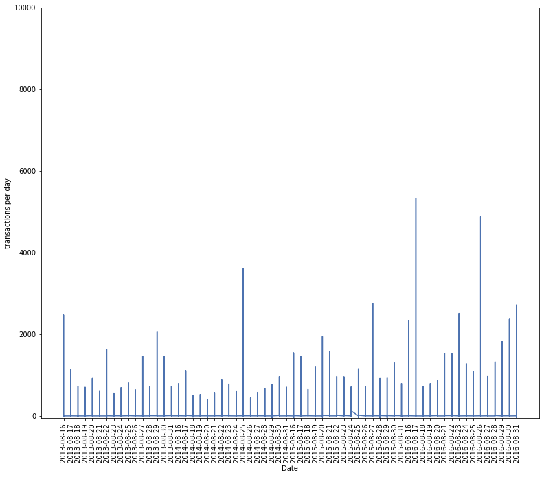

```python
plt.style.use('seaborn-deep')
plt.figure(figsize=(13,11))
plt.plot(grocery_train.date.values, grocery_train.unit_sales)
plt.ylim(-50, 10000)
plt.ylabel('transactions per day')
plt.xlabel('Date')
plt.xticks(rotation=90)
plt.show()
```

We can see that there are days that have extremely more transactions - maybe weekends or holidays.

```python
test =  pd.read_csv('/content/drive/MyDrive/DeepLearning/Assignment2/test.csv')
```

```python
len(test)
```

```
3370464
```

```python
print(len(test))
check_test = test.copy()
check_test['date'] = pd.to_datetime(check_test['date'], errors='coerce')
check_test = check_test[(check_test['date'].dt.month == 8) & (check_test['date'].dt.day > 15)]
print(len(check_test))
test.head()
```

```
3370464
3370464
```

|  | id | date | store_nbr | item_nbr | onpromotion |
| --- | --- | --- | --- | --- | --- |
| 0 | 125497040 | 2017-08-16 | 1 | 96995 | False |
| 1 | 125497041 | 2017-08-16 | 1 | 99197 | False |
| 2 | 125497042 | 2017-08-16 | 1 | 103501 | False |
| 3 | 125497043 | 2017-08-16 | 1 | 103520 | False |
| 4 | 125497044 | 2017-08-16 | 1 | 103665 | False |

**We can see that all the values in test are between 16/8 - 31/8!**

Items -

```python
items =  pd.read_csv('/content/drive/MyDrive/DeepLearning/Assignment2/items.csv')
```

```python
print(len(items))
items.head()
```

```
4100
```

|  | item_nbr | family | class | perishable |
| --- | --- | --- | --- | --- |
| 0 | 96995 | GROCERY I | 1093 | 0 |
| 1 | 99197 | GROCERY I | 1067 | 0 |
| 2 | 103501 | CLEANING | 3008 | 0 |
| 3 | 103520 | GROCERY I | 1028 | 0 |
| 4 | 103665 | BREAD/BAKERY | 2712 | 1 |

```python
import plotly.graph_objs as go
import plotly.offline as py
x, y = (list(x) for x in zip(*sorted(zip(items.family.value_counts().index,
                                         items.family.value_counts().values),
                                        reverse = False)))
trace2 = go.Bar(
    y=items.family.value_counts().values,
    x=items.family.value_counts().index,
    marker=dict(
        color=items.family.value_counts().values,
        colorscale = 'Portland',
        reversescale = False
    ),
    orientation='v',
)

layout = dict(
    title='Counts of items per family category',
     width = 800, height = 800,
    yaxis=dict(
        showgrid=False,
        showline=False,
        showticklabels=True,
#         domain=[0, 0.85],
    ))

fig1 = go.Figure(data=[trace2])
fig1['layout'].update(layout)
py.iplot(fig1, filename='plots')
```

[interactive chart not shown]

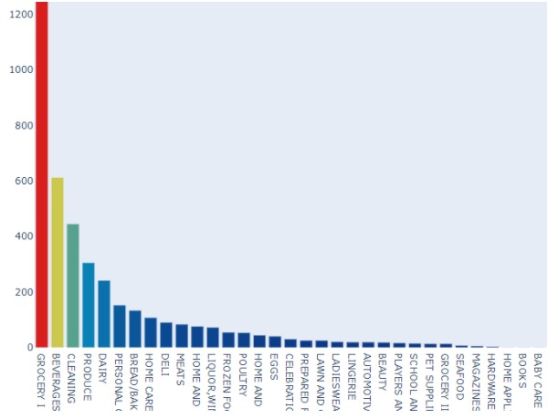

```python
display_image('items.jpg')
```

We can see that the items have different amounts for each family category.

**Transactions**

```python
transactions =  pd.read_csv('/content/drive/MyDrive/DeepLearning/Assignment2/transactions.csv')
```

```python
transactions['date'] = pd.to_datetime(transactions['date'], errors='coerce')
transactions = transactions[(transactions['date'].dt.month == 8) & (transactions['date'].dt.day > 15)]
transactions['date'] = transactions['date'].dt.strftime('%Y-%m-%d')
```

```python
print(len(transactions))
transactions.head()
```

[output not shown]

[output not shown]

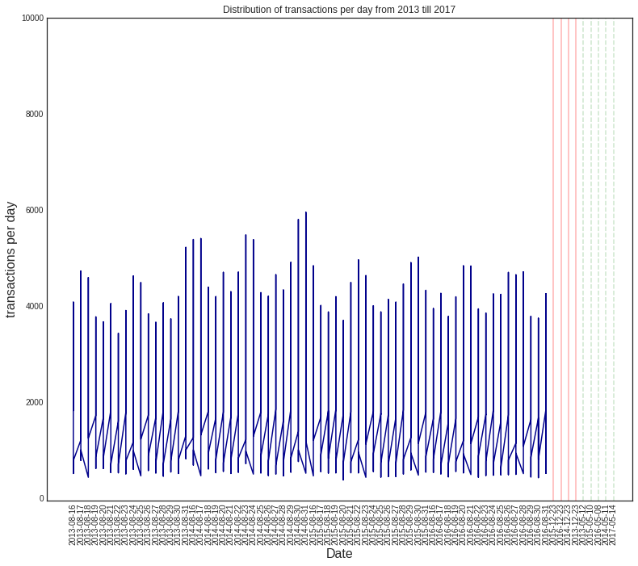

```python
plt.style.use('seaborn-white')
plt.figure(figsize=(13,11))
plt.plot(transactions.date.values, transactions.transactions.values, color='darkblue')
plt.axvline(x='2015-12-23',color='red',alpha=0.3)
plt.axvline(x='2016-12-23',color='red',alpha=0.3)
plt.axvline(x='2014-12-23',color='red',alpha=0.3)
plt.axvline(x='2013-12-23',color='red',alpha=0.3)
plt.axvline(x='2013-05-12',color='green',alpha=0.2, linestyle= '--')
plt.axvline(x='2015-05-10',color='green',alpha=0.2, linestyle= '--')
plt.axvline(x='2016-05-08',color='green',alpha=0.2, linestyle= '--')
plt.axvline(x='2014-05-11',color='green',alpha=0.2, linestyle= '--')
plt.axvline(x='2017-05-14',color='green',alpha=0.2, linestyle= '--')
plt.ylim(-50, 10000)
plt.title("Distribution of transactions per day from 2013 till 2017")
plt.ylabel('transactions per day', fontsize= 16)
plt.xlabel('Date', fontsize= 16)
plt.xticks(rotation=90)
plt.show()
```

**Holidays Events**

```python
holidays_events =  pd.read_csv('/content/drive/MyDrive/DeepLearning/Assignment2/holidays_events.csv')
```

```python
holidays_events['date'] = pd.to_datetime(holidays_events['date'], errors='coerce')
holidays_events = holidays_events[(holidays_events['date'].dt.month == 8) & (holidays_events['date'].dt.day > 15)]
holidays_events['date'] = holidays_events['date'].dt.strftime('%Y-%m-%d')
```

```python
print(len(holidays_events))
holidays_events
```

```
6
```

|  | date | type | locale | locale_name | description | transferred |
| --- | --- | --- | --- | --- | --- | --- |
| 16 | 2012-08-24 | Holiday | Local | Ambato | Fundacion de Ambato | False |
| 69 | 2013-08-24 | Holiday | Local | Ambato | Fundacion de Ambato | False |
| 132 | 2014-08-24 | Holiday | Local | Ambato | Fundacion de Ambato | False |
| 187 | 2015-08-24 | Holiday | Local | Ambato | Fundacion de Ambato | False |
| 271 | 2016-08-24 | Holiday | Local | Ambato | Fundacion de Ambato | False |
| 327 | 2017-08-24 | Holiday | Local | Ambato | Fundacion de Ambato | False |

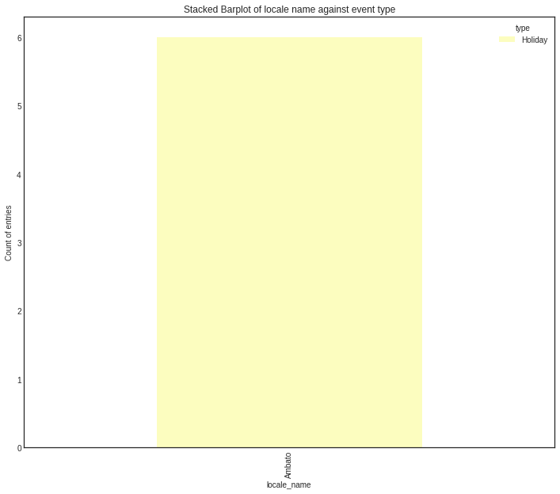

```python
plt.style.use('seaborn-white')
# plt.style.use('dark_background')
holiday_local_type = holidays_events.groupby(['locale_name', 'type']).size()
holiday_local_type.unstack().plot(kind='bar',stacked=True, colormap= 'magma_r', figsize=(12,10),  grid=False)
plt.title('Stacked Barplot of locale name against event type')
plt.ylabel('Count of entries')
plt.show()
```

We can see that there is only one holiday in these dates!

**Stores**

```python
stores =  pd.read_csv('/content/drive/MyDrive/DeepLearning/Assignment2/stores.csv')
```

```python
print(len(stores))
stores.head()
```

```
54
```

|  | store_nbr | city | state | type | cluster |
| --- | --- | --- | --- | --- | --- |
| 0 | 1 | Quito | Pichincha | D | 13 |
| 1 | 2 | Quito | Pichincha | D | 13 |
| 2 | 3 | Quito | Pichincha | D | 8 |
| 3 | 4 | Quito | Pichincha | D | 9 |
| 4 | 5 | Santo Domingo | Santo Domingo de los Tsachilas | D | 4 |

**Oil**

```python
oil = pd.read_csv('/content/drive/MyDrive/DeepLearning/Assignment2/oil.csv')
```

```python
print(oil.shape)
print(oil.isnull().values.any())
oil = interpolate_nan_values(oil)
print(oil.isnull().values.any())
```

```
Interpolating data columns containing NaN: 100%|██████████| 2/2 [00:00<00:00, 364.60it/s]
```

```
(1218, 2)
True
False
```

We saw that there are nan values in oil data, so we interpolated the data.

```python
oil.head()
```

|  | date | dcoilwtico |
| --- | --- | --- |
| 0 | 2013-01-01 | 93.14 |
| 1 | 2013-01-02 | 93.14 |
| 2 | 2013-01-03 | 92.97 |
| 3 | 2013-01-04 | 93.12 |
| 4 | 2013-01-07 | 93.20 |

```python
trace = go.Scatter(
    name='Oil prices',
    x=oil['date'],
    y=oil['dcoilwtico'].dropna(),
    mode='lines',
    line=dict(color='rgb(20, 15, 200, 0.8)'),
    #fillcolor='rgba(68, 68, 68, 0.3)',
    fillcolor='rgba(0, 0, 216, 0.3)',
    fill='tonexty' )

data = [trace]

layout = go.Layout(
    yaxis=dict(title='Daily Oil price'),
    title='Daily oil prices from Jan 2013 till July 2017',
    showlegend = False)
fig = go.Figure(data=data, layout=layout)
py.iplot(fig, filename='pandas-time-series-error-bars')
```

[interactive chart not shown]

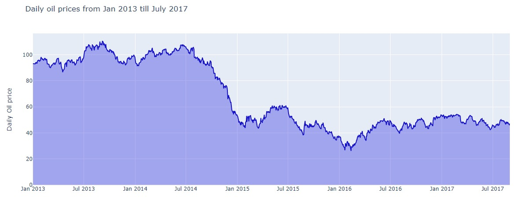

```python
display_image('oil.jpg')
```

**3.c)**

- Add the merged data
- preprocess the data such that we can use embeddings

First, we merged the transactions, stores and holidays_events data togther to one data set

```python
grocery_train = pd.merge(grocery_train, items, on='item_nbr', how='left')
grocery_train = pd.merge(grocery_train, transactions, on=['date', 'store_nbr'], how='left')
grocery_train = pd.merge(grocery_train, stores, on='store_nbr', how='left')
grocery_train = pd.merge(grocery_train, holidays_events, on='date', how='left')
```

```python
# grocery_train = interpolate_nan_values(grocery_train)
```

Now, we checked if there is a null value in the dataset

```python
print(grocery_train.isna().any())
grocery_train.head()
```

```
id              False
date            False
store_nbr       False
item_nbr        False
unit_sales      False
onpromotion     False
family          False
class           False
perishable      False
transactions    False
city            False
state           False
type_x          False
cluster         False
type_y           True
locale           True
locale_name      True
description      True
transferred      True
dtype: bool
```

|  | id | date | store_nbr | item_nbr | unit_sales | onpromotion | family | class | perishable | transactions | city | state | type_x | cluster | type_y | locale | locale_name | description | transferred |
| --- | --- | --- | --- | --- | --- | --- | --- | --- | --- | --- | --- | --- | --- | --- | --- | --- | --- | --- | --- |
| 0 | 9767476 | 2013-08-16 | 1 | 96995 | 3.0 | False | GROCERY I | 1093 | 0 | 1817 | Quito | Pichincha | D | 13 | NaN | NaN | NaN | NaN | NaN |
| 1 | 9767477 | 2013-08-16 | 1 | 103665 | 2.0 | False | BREAD/BAKERY | 2712 | 1 | 1817 | Quito | Pichincha | D | 13 | NaN | NaN | NaN | NaN | NaN |
| 2 | 9767478 | 2013-08-16 | 1 | 105574 | 4.0 | False | GROCERY I | 1045 | 0 | 1817 | Quito | Pichincha | D | 13 | NaN | NaN | NaN | NaN | NaN |
| 3 | 9767479 | 2013-08-16 | 1 | 105575 | 11.0 | False | GROCERY I | 1045 | 0 | 1817 | Quito | Pichincha | D | 13 | NaN | NaN | NaN | NaN | NaN |
| 4 | 9767480 | 2013-08-16 | 1 | 105577 | 6.0 | False | GROCERY I | 1045 | 0 | 1817 | Quito | Pichincha | D | 13 | NaN | NaN | NaN | NaN | NaN |

The only null value come from the holiday data set. we decided to encoded all the nulls the same, which said there is no holday for that data row.

Now, we encoded all data set

```python
# date_nbr = {p:i for (i,p) in enumerate(grocery_train['date'].unique())}
store_nbr = {p:i for (i,p) in enumerate(grocery_train['store_nbr'].unique())}
item_nbr = {p:i for (i,p) in enumerate(grocery_train['item_nbr'].unique())}
onpromotion_nbr = {p:i for (i,p) in enumerate(grocery_train['onpromotion'].unique())}
family_nbr = {p:i for (i,p) in enumerate(grocery_train['family'].unique())}
class_nbr = {p:i for (i,p) in enumerate(grocery_train['class'].unique())}
perishable_nbr = {p:i for (i,p) in enumerate(grocery_train['perishable'].unique())}
transactions_nbr = {p:i for (i,p) in enumerate(grocery_train['transactions'].unique())}
city_nbr = {p:i for (i,p) in enumerate(grocery_train['city'].unique())}
state_nbr = {p:i for (i,p) in enumerate(grocery_train['state'].unique())}
type_x_nbr = {p:i for (i,p) in enumerate(grocery_train['type_x'].unique())}
cluster_nbr = {p:i for (i,p) in enumerate(grocery_train['cluster'].unique())}
type_y_nbr = {p:i for (i,p) in enumerate(grocery_train['type_y'].unique())}
locale_nbr = {p:i for (i,p) in enumerate(grocery_train['locale'].unique())}
locale_name_nbr = {p:i for (i,p) in enumerate(grocery_train['locale_name'].unique())}
transferred_nbr = {p:i for (i,p) in enumerate(grocery_train['transferred'].unique())}

# dcoilwtico = grocery_train['dcoilwtico'].values
```

Now, we create processed data, which concluds all the encoded data

```python
processed_data = grocery_train.loc[:,['store_nbr','item_nbr', 'onpromotion', 'family', 'class', 'perishable', 'transactions', 'city', 'state', 'type_x', 'cluster', 'type_y', 'locale', 'locale_name', 'transferred']].copy()
# processed_data['date'] = [date_nbr[x] for x in grocery_train['date']]
processed_data['store_nbr'] = [store_nbr[x] for x in grocery_train['store_nbr']]
processed_data['item_nbr'] = [item_nbr[x] for x in grocery_train['item_nbr']]
processed_data['onpromotion'] = [onpromotion_nbr[x] for x in grocery_train['onpromotion']]
processed_data['family'] = [family_nbr[x] for x in grocery_train['family']]
processed_data['class'] = [class_nbr[x] for x in grocery_train['class']]
processed_data['perishable'] = [perishable_nbr[x] for x in grocery_train['perishable']]
processed_data['transactions'] = [transactions_nbr[x] for x in grocery_train['transactions']]
processed_data['city'] = [city_nbr[x] for x in grocery_train['city']]
processed_data['state'] = [state_nbr[x] for x in grocery_train['state']]
processed_data['type_x'] = [type_x_nbr[x] for x in grocery_train['type_x']]
processed_data['cluster'] = [cluster_nbr[x] for x in grocery_train['cluster']]
processed_data['type_y'] = [type_y_nbr[x] for x in grocery_train['type_y']]
processed_data['locale'] = [locale_nbr[x] for x in grocery_train['locale']]
processed_data['locale_name'] = [locale_name_nbr[x] for x in grocery_train['locale_name']]
processed_data['transferred'] = [transferred_nbr[x] for x in grocery_train['transferred']]
target = grocery_train['unit_sales'].values
```

Now, we do all the prepration process to the test data

```python
test_data = pd.merge(test, items, on='item_nbr', how='left')
test_data = pd.merge(test_data, transactions, on=['date', 'store_nbr'], how='left')
test_data = pd.merge(test_data, stores, on='store_nbr', how='left')
test_data = pd.merge(test_data, holidays_events, on='date', how='left')
```

Generate test data, for each elemnt how as no value in the train data, we encode it such it will have encode

```python
for (i,p) in enumerate(test_data['store_nbr'].unique()):
  if p not in store_nbr:
    store_nbr[p] = i
for (i,p) in enumerate(test_data['item_nbr'].unique()):
  if p not in item_nbr:
    item_nbr[p] = i
for (i,p) in enumerate(test_data['family'].unique()):
  if p not in family_nbr:
    family_nbr[p] = i
for (i,p) in enumerate(test_data['class'].unique()):
  if p not in class_nbr:
    class_nbr[p] = i


processed_test_data = test_data.loc[:,['store_nbr','item_nbr', 'onpromotion', 'family', 'class', 'perishable', 'transactions', 'city', 'state', 'type_x', 'cluster', 'type_y', 'locale', 'locale_name', 'transferred']].copy()
# processed_test_data['date'] = [test_date_nbr[x] for x in test_data['date']]
processed_test_data['store_nbr'] = [store_nbr[x] for x in test_data['store_nbr']]
processed_test_data['item_nbr'] = [item_nbr[x] for x in test_data['item_nbr']]
processed_test_data['onpromotion'] = [onpromotion_nbr[x] for x in test_data['onpromotion']]
processed_test_data['family'] = [family_nbr[x] for x in test_data['family']]
processed_test_data['class'] = [class_nbr[x] for x in test_data['class']]
processed_test_data['perishable'] = [perishable_nbr[x] for x in test_data['perishable']]
processed_test_data['transactions'] = [0 for x in test_data['transactions']]
processed_test_data['city'] = [city_nbr[x] for x in test_data['city']]
processed_test_data['state'] = [state_nbr[x] for x in test_data['state']]
processed_test_data['type_x'] = [type_x_nbr[x] for x in test_data['type_x']]
processed_test_data['cluster'] = [cluster_nbr[x] for x in test_data['cluster']]
processed_test_data['type_y'] = [type_y_nbr[x] for x in test_data['type_y']]
processed_test_data['locale'] = [locale_nbr[x] for x in test_data['locale']]
processed_test_data['locale_name'] = [locale_name_nbr[x] for x in test_data['locale_name']]
processed_test_data['transferred'] = [transferred_nbr[x] for x in test_data['transferred']]
```

**3.b)** Since we have a regression problem, we choose to use RandomForestRegressor as the solid bench mark.

```python
from sklearn.ensemble import RandomForestRegressor
from sklearn.model_selection   import train_test_split
rf = RandomForestRegressor(n_estimators=20, verbose=2)

x_train, x_val, y_train, y_val = train_test_split(processed_data, target, test_size=0.2, random_state=42)
```

```python
rf.fit(processed_data, target)
```

```
[Parallel(n_jobs=1)]: Using backend SequentialBackend with 1 concurrent workers.
```

```
building tree 1 of 20
```

```
[Parallel(n_jobs=1)]: Done   1 out of   1 | elapsed:    6.2s remaining:    0.0s
```

```
building tree 2 of 20
building tree 3 of 20
building tree 4 of 20
building tree 5 of 20
building tree 6 of 20
building tree 7 of 20
building tree 8 of 20
building tree 9 of 20
building tree 10 of 20
building tree 11 of 20
building tree 12 of 20
building tree 13 of 20
building tree 14 of 20
building tree 15 of 20
building tree 16 of 20
building tree 17 of 20
building tree 18 of 20
building tree 19 of 20
building tree 20 of 20
```

```
[Parallel(n_jobs=1)]: Done  20 out of  20 | elapsed:  2.1min finished
```

```
RandomForestRegressor(bootstrap=True, ccp_alpha=0.0, criterion='mse',
                      max_depth=None, max_features='auto', max_leaf_nodes=None,
                      max_samples=None, min_impurity_decrease=0.0,
                      min_impurity_split=None, min_samples_leaf=1,
                      min_samples_split=2, min_weight_fraction_leaf=0.0,
                      n_estimators=20, n_jobs=None, oob_score=False,
                      random_state=None, verbose=2, warm_start=False)
```

Now, lets check the results of random forest regressor

```python
import numpy as np
from sklearn.metrics import mean_absolute_error
predictions = rf.predict(x_val)
errors = abs(predictions - y_val)
# print('Mean Absolute Error:', round(np.mean(errors), 2), 'degrees.')
mean_absolute_error(y_val, predictions)
```

```
[Parallel(n_jobs=1)]: Using backend SequentialBackend with 1 concurrent workers.
[Parallel(n_jobs=1)]: Done   1 out of   1 | elapsed:    0.1s remaining:    0.0s
[Parallel(n_jobs=1)]: Done  20 out of  20 | elapsed:    2.9s finished
```

```
1.4987398346077687
```

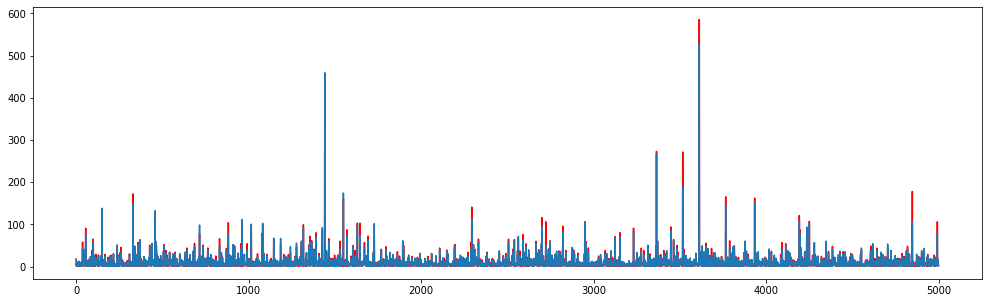

```python
plt.figure(figsize=(17,5))
plt.plot(y_val[:5000],c='red')
plt.plot(predictions[:5000])
```

```python
predictions = rf.predict(processed_test_data)
```

```python
def submit(predictions):
  test_id = test.loc[:,['id']]
  results = pd.DataFrame({'unit_sales':predictions})
  to_sub = pd.concat([test_id, results], axis=1)
  to_sub.to_csv('/content/drive/MyDrive/DeepLearning/Assignment2/sub.csv', index=False)
```

```python
submit(predictions)
```

We scored on kaggle 1.45468

- We can see that random forest receives a good benchmark result.
- We can see from the graph that random forest success to generalize the data and to predict well the extreme values.

**3.d)** Now we will try to take only store_nbr and item_nbr and perform first model attention

```python
processed_data_first = grocery_train.loc[:,['store_nbr','item_nbr']].copy()
processed_data_first['store_nbr'] = [store_nbr[x] for x in grocery_train['store_nbr']]
processed_data_first['item_nbr'] = [item_nbr[x] for x in grocery_train['item_nbr']]
target = grocery_train['unit_sales'].values
```

[output not shown]

```python
from keras.layers import *
from keras.regularizers import l2
from keras.models import Model, Sequential
from keras.optimizers import Adam, SGD
from keras.callbacks import TensorBoard, ModelCheckpoint, EarlyStopping
from keras.utils import to_categorical
import keras
import keras.utils
from keras import utils as np_utils
from math import log
```

For First try, we wanted a simple NN with embeddings, to see how it works, and what is the baseline results.

```python
def create_model():
  store_nbr_inp = Input(shape=(1,),dtype='int64')
  item_nbr_inp = Input(shape=(1,),dtype='int64')

  store_nbr_emb = Embedding(len(store_nbr),5,input_length=1, embeddings_regularizer=l2(1e-6))(store_nbr_inp)
  item_nbr_emb = Embedding(len(item_nbr),5,input_length=1, embeddings_regularizer=l2(1e-6))(item_nbr_inp)

  x = concatenate([store_nbr_emb,item_nbr_emb])
  x = Flatten()(x)
  x = BatchNormalization()(x)
  x = Dense(10,activation='relu')(x)
  x = BatchNormalization()(x)
  x = Dense(10,activation='relu')(x)
  x = Dense(1,activation='relu')(x)
  nn_model = Model([store_nbr_inp,item_nbr_inp],x)
  nn_model.compile(loss = 'msle',optimizer='sgd', metrics=['acc'])
  return nn_model
```

```python
create_model().summary()
```

```
Model: "model_4"
__________________________________________________________________________________________________
Layer (type)                    Output Shape         Param #     Connected to
==================================================================================================
input_33 (InputLayer)           [(None, 1)]          0
__________________________________________________________________________________________________
input_34 (InputLayer)           [(None, 1)]          0
__________________________________________________________________________________________________
embedding_32 (Embedding)        (None, 1, 5)         270         input_33[0][0]
__________________________________________________________________________________________________
embedding_33 (Embedding)        (None, 1, 5)         20365       input_34[0][0]
__________________________________________________________________________________________________
concatenate_3 (Concatenate)     (None, 1, 10)        0           embedding_32[0][0]
                                                                 embedding_33[0][0]
__________________________________________________________________________________________________
flatten_3 (Flatten)             (None, 10)           0           concatenate_3[0][0]
__________________________________________________________________________________________________
batch_normalization_14 (BatchNo (None, 10)           40          flatten_3[0][0]
__________________________________________________________________________________________________
dense_15 (Dense)                (None, 10)           110         batch_normalization_14[0][0]
__________________________________________________________________________________________________
batch_normalization_15 (BatchNo (None, 10)           40          dense_15[0][0]
__________________________________________________________________________________________________
dense_16 (Dense)                (None, 10)           110         batch_normalization_15[0][0]
__________________________________________________________________________________________________
dense_17 (Dense)                (None, 1)            11          dense_16[0][0]
==================================================================================================
Total params: 20,946
Trainable params: 20,906
Non-trainable params: 40
__________________________________________________________________________________________________
```

```python
from os.path import join
from tensorflow.keras.callbacks import EarlyStopping, ModelCheckpoint, ReduceLROnPlateau
model_save_dir = '/content/drive/MyDrive/DeepLearning/Assignment2/models'

def get_callbacks(saved_model_name):
    early_stopping_callback = EarlyStopping(monitor="val_loss", patience=3, verbose=2)
    rlop_callback = ReduceLROnPlateau(patience=3)
    checkpoint_callback = ModelCheckpoint(join(model_save_dir, f'model_{saved_model_name}.h5'),
                                                monitor='val_loss', verbose=1,
                                                save_best_only=True, mode='min')
    return [early_stopping_callback, checkpoint_callback, rlop_callback]
```

```python
import numpy as np
def save_history(history, model_name):
    np.save('/content/drive/MyDrive/DeepLearning/Assignment2/history/' + f'{model_name}_history.npy', history.history)

def load_history(model_name):
    return np.load('/content/drive/MyDrive/DeepLearning/Assignment2/history/' + f'{model_name}_history.npy', allow_pickle='TRUE').item()
```

```python
from sklearn.model_selection import KFold,StratifiedKFold

def set_callbacks(description='run1',patience=15,tb_base_logdir='./logs/'):
    cp = ModelCheckpoint('best_model_weights_{}.h5'.format(description),save_best_only=True)
    es = EarlyStopping(patience=patience,monitor='val_loss')
    rlop = ReduceLROnPlateau(patience=5)
    tb = TensorBoard(log_dir='{}{}'.format(tb_base_logdir,description))
#     cycl = CyclicLR(max_lr=0.03,step_size=5000)
    cb = [cp,es,tb,rlop]
    return cb

features = processed_data.columns

train_num = int(len(processed_data_first) * 0.8)

x_train = processed_data_first[:train_num]
y_train = target[:train_num]
x_val= processed_data_first[train_num:]
y_val = target[train_num:]

nn_model = create_model()

history = nn_model.fit([x_train[f] for f in processed_data_first.columns], y_train, batch_size=64,
          epochs=15,
          validation_data=([x_val[f] for f in processed_data_first.columns], y_val),
          callbacks= get_callbacks('simple_embbeding'),
          verbose=1
         )

save_history(history, model_name='simple_embbeding')
```

```
Epoch 00001: val_loss improved from inf to 0.36490, saving model to /content/drive/MyDrive/DeepLearning/Assignment2/models/model_simple_embbeding.h5

Epoch 00002: val_loss improved from 0.36490 to 0.35063, saving model to /content/drive/MyDrive/DeepLearning/Assignment2/models/model_simple_embbeding.h5

Epoch 00003: val_loss improved from 0.35063 to 0.33820, saving model to /content/drive/MyDrive/DeepLearning/Assignment2/models/model_simple_embbeding.h5

Epoch 00004: val_loss improved from 0.33820 to 0.33806, saving model to /content/drive/MyDrive/DeepLearning/Assignment2/models/model_simple_embbeding.h5

Epoch 00005: val_loss improved from 0.33806 to 0.33142, saving model to /content/drive/MyDrive/DeepLearning/Assignment2/models/model_simple_embbeding.h5

Epoch 00006: val_loss improved from 0.33142 to 0.33065, saving model to /content/drive/MyDrive/DeepLearning/Assignment2/models/model_simple_embbeding.h5

Epoch 00007: val_loss improved from 0.33065 to 0.32766, saving model to /content/drive/MyDrive/DeepLearning/Assignment2/models/model_simple_embbeding.h5

Epoch 00008: val_loss did not improve from 0.32766

Epoch 00009: val_loss did not improve from 0.32766

Epoch 00010: val_loss improved from 0.32766 to 0.32705, saving model to /content/drive/MyDrive/DeepLearning/Assignment2/models/model_simple_embbeding.h5

Epoch 00011: val_loss did not improve from 0.32705

Epoch 00012: val_loss improved from 0.32705 to 0.32667, saving model to /content/drive/MyDrive/DeepLearning/Assignment2/models/model_simple_embbeding.h5

Epoch 00013: val_loss did not improve from 0.32667

Epoch 00014: val_loss improved from 0.32667 to 0.32577, saving model to /content/drive/MyDrive/DeepLearning/Assignment2/models/model_simple_embbeding.h5

Epoch 00015: val_loss did not improve from 0.32577
```

```python
def plot_history(history, plot_title):
    fig, axes = plt.subplots(nrows=1, ncols=1, figsize=(18, 6))

    # Plot training & validation accuracy values
    # axes[0].plot(history['accuracy'])
    # axes[0].plot(history['val_accuracy'])
    # axes[0].set_title('Model accuracy')
    # axes[0].set_ylabel('Accuracy')
    # axes[0].set_xlabel('Epoch')
    # axes[0].legend(['Train', 'Validation'], loc='lower right')
    # axes[0].grid()

    # Plot training & validation loss values
    axes.plot(history['loss'])
    axes.plot(history['val_loss'])
    axes.set_title('Model loss')
    axes.set_ylabel('Loss')
    axes.set_xlabel('Epoch')
    axes.legend(['Train', 'Validation'], loc='upper right')
    axes.grid()
    # fig.suptitle(plot_title + " Model")
    plt.tight_layout()
    plt.show()
```

```python
def plot_model_history(model_name):
    history = load_history(model_name)
    plot_title = model_name.replace("_", " ").title().replace("Lstm", "LSTM")
    plot_history(history, plot_title)
```

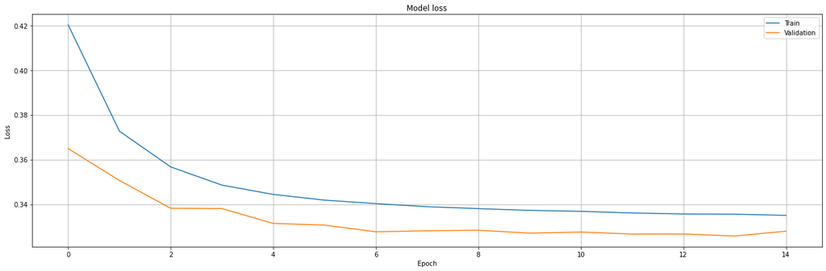

```python
plot_model_history('simple_embbeding')
```

```python
nn_model = create_model()
nn_model.load_weights('/content/drive/MyDrive/DeepLearning/Assignment2/models/model_simple_embbeding.h5')
```

```python
predictions = nn_model.predict([processed_data_first[f] for f in processed_data_first.columns])
```

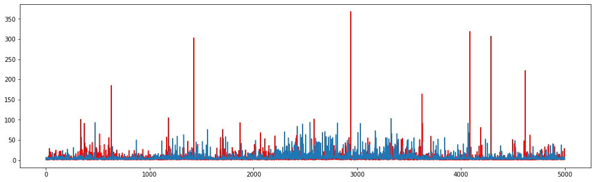

```python
plt.figure(figsize=(17,5))
plt.plot(y_val[:5000],c='red')
plt.plot(predictions[:5000,0])
```

We can see the we recived much lower results than the benchmark. we can try to improve it by:

- Add featers from the other data sets with embeddings.
  - we can see that the algorithm fail to recognize the extreme values, that why adding embeddings that contains holidays for example may help.
- Add other model network to model the time series part of the model.

Let's try to improve the model by adding more embbedings

```python
def create_concate_model():
  # date_nbr_inp = Input(shape=(1,),dtype='int64')
  store_nbr_inp = Input(shape=(1,),dtype='int64')
  item_nbr_inp = Input(shape=(1,),dtype='int64')
  onpromotion_nbr_inp = Input(shape=(1,),dtype='int64')
  family_nbr_inp = Input(shape=(1,),dtype='int64')
  class_nbr_inp = Input(shape=(1,),dtype='int64')
  perishable_nbr_inp = Input(shape=(1,),dtype='int64')
  transactions_nbr_inp = Input(shape=(1,),dtype='int64')
  city_nbr_inp = Input(shape=(1,),dtype='int64')
  state_nbr_inp = Input(shape=(1,),dtype='int64')
  type_x_nbr_inp = Input(shape=(1,),dtype='int64')
  cluster_nbr_inp = Input(shape=(1,),dtype='int64')
  type_y_nbr_inp = Input(shape=(1,),dtype='int64')
  locale_nbr_inp = Input(shape=(1,),dtype='int64')
  locale_name_nbr_inp = Input(shape=(1,),dtype='int64')
  transferred_nbr_inp = Input(shape=(1,),dtype='int64')


  # date_nbr_emb = Embedding(len(date_nbr),5,input_length=1, embeddings_regularizer=l2(1e-6))(date_nbr_inp)
  store_nbr_emb = Embedding(len(store_nbr),5,input_length=1, embeddings_regularizer=l2(1e-6))(store_nbr_inp)
  item_nbr_emb = Embedding(len(item_nbr),5,input_length=1, embeddings_regularizer=l2(1e-6))(item_nbr_inp)
  onpromotion_nbr_emb = Embedding(len(onpromotion_nbr),5,input_length=1, embeddings_regularizer=l2(1e-6))(onpromotion_nbr_inp)
  family_nbr_emb = Embedding(len(family_nbr),5,input_length=1, embeddings_regularizer=l2(1e-6))(family_nbr_inp)
  class_nbr_emb = Embedding(len(class_nbr),5,input_length=1, embeddings_regularizer=l2(1e-6))(class_nbr_inp)
  perishable_nbr_emb = Embedding(len(perishable_nbr),5,input_length=1, embeddings_regularizer=l2(1e-6))(perishable_nbr_inp)
  transactions_nbr_emb = Embedding(len(transactions_nbr),5,input_length=1, embeddings_regularizer=l2(1e-6))(transactions_nbr_inp)
  city_nbr_emb = Embedding(len(city_nbr),5,input_length=1, embeddings_regularizer=l2(1e-6))(city_nbr_inp)
  state_nbr_emb = Embedding(len(state_nbr),5,input_length=1, embeddings_regularizer=l2(1e-6))(state_nbr_inp)
  type_x_nbr_emb = Embedding(len(type_x_nbr),5,input_length=1, embeddings_regularizer=l2(1e-6))(type_x_nbr_inp)
  cluster_nbr_emb = Embedding(len(cluster_nbr),5,input_length=1, embeddings_regularizer=l2(1e-6))(cluster_nbr_inp)
  type_y_nbr_emb = Embedding(len(type_y_nbr),5,input_length=1, embeddings_regularizer=l2(1e-6))(type_y_nbr_inp)
  locale_nbr_emb = Embedding(len(locale_nbr),5,input_length=1, embeddings_regularizer=l2(1e-6))(locale_nbr_inp)
  locale_name_nbr_emb = Embedding(len(locale_name_nbr),5,input_length=1, embeddings_regularizer=l2(1e-6))(locale_name_nbr_inp)
  transferred_nbr_emb = Embedding(len(transferred_nbr),5,input_length=1, embeddings_regularizer=l2(1e-6))(transferred_nbr_inp)

  train_num = int(len(processed_data) * 0.8)

  x = Concatenate()([store_nbr_emb,item_nbr_emb, onpromotion_nbr_emb, family_nbr_emb, class_nbr_emb, perishable_nbr_emb, transactions_nbr_emb, city_nbr_emb, state_nbr_emb, type_x_nbr_emb, cluster_nbr_emb, type_y_nbr_emb, locale_nbr_emb, locale_name_nbr_emb, transferred_nbr_emb])
  x = Flatten()(x)
  x = BatchNormalization()(x)
  x = Dense(100,activation='relu')(x)
  x = Dense(100,activation='relu')(x)
  x = BatchNormalization()(x)
  x = Dense(100,activation='relu')(x)
  x = Dense(100,activation='relu')(x)
  x = Dense(1,activation='relu')(x)
  nn_model = Model([store_nbr_inp,item_nbr_inp, onpromotion_nbr_inp, family_nbr_inp, class_nbr_inp, perishable_nbr_inp, transactions_nbr_inp, city_nbr_inp, state_nbr_inp, type_x_nbr_inp, cluster_nbr_inp, type_y_nbr_inp, locale_nbr_inp, locale_name_nbr_inp, transferred_nbr_inp],x)
  nn_model.compile(loss = 'msle',optimizer='sgd', metrics=['acc'])
  return nn_model
```

```python
create_concate_model().summary()
```

[output not shown]

[output cut: 30 more lines]

[output not shown]

```python
from sklearn.model_selection import KFold,StratifiedKFold

def set_callbacks(description='run1',patience=15,tb_base_logdir='./logs/'):
    cp = ModelCheckpoint('best_model_weights_{}.h5'.format(description),save_best_only=True)
    es = EarlyStopping(patience=patience,monitor='val_loss')
    rlop = ReduceLROnPlateau(patience=5)
    tb = TensorBoard(log_dir='{}{}'.format(tb_base_logdir,description))
#     cycl = CyclicLR(max_lr=0.03,step_size=5000)
    cb = [cp,es,tb,rlop]
    return cb

features = processed_data.columns


x_train, x_val, y_train, y_val = train_test_split(processed_data, target, test_size=0.2, random_state=42)


nn_model = create_concate_model()

history = nn_model.fit([x_train[f] for f in processed_data.columns], y_train, batch_size=64,
          epochs=15,
          validation_data=([x_val[f] for f in processed_data.columns], y_val),
          callbacks= get_callbacks('concat_embbeding'),
          verbose=1
         )

save_history(history, model_name='concat_embbeding')
```

```
Epoch 00001: val_loss improved from inf to 0.39226, saving model to /content/drive/MyDrive/DeepLearning/Assignment2/models/model_concat_embbeding.h5

Epoch 00002: val_loss improved from 0.39226 to 0.34939, saving model to /content/drive/MyDrive/DeepLearning/Assignment2/models/model_concat_embbeding.h5

Epoch 00003: val_loss improved from 0.34939 to 0.32883, saving model to /content/drive/MyDrive/DeepLearning/Assignment2/models/model_concat_embbeding.h5

Epoch 00004: val_loss improved from 0.32883 to 0.31533, saving model to /content/drive/MyDrive/DeepLearning/Assignment2/models/model_concat_embbeding.h5

Epoch 00005: val_loss improved from 0.31533 to 0.30939, saving model to /content/drive/MyDrive/DeepLearning/Assignment2/models/model_concat_embbeding.h5

Epoch 00006: val_loss improved from 0.30939 to 0.30553, saving model to /content/drive/MyDrive/DeepLearning/Assignment2/models/model_concat_embbeding.h5

Epoch 00007: val_loss improved from 0.30553 to 0.30300, saving model to /content/drive/MyDrive/DeepLearning/Assignment2/models/model_concat_embbeding.h5

Epoch 00008: val_loss improved from 0.30300 to 0.30271, saving model to /content/drive/MyDrive/DeepLearning/Assignment2/models/model_concat_embbeding.h5

Epoch 00009: val_loss improved from 0.30271 to 0.29888, saving model to /content/drive/MyDrive/DeepLearning/Assignment2/models/model_concat_embbeding.h5

Epoch 00010: val_loss improved from 0.29888 to 0.29807, saving model to /content/drive/MyDrive/DeepLearning/Assignment2/models/model_concat_embbeding.h5

Epoch 00011: val_loss improved from 0.29807 to 0.29615, saving model to /content/drive/MyDrive/DeepLearning/Assignment2/models/model_concat_embbeding.h5

Epoch 00012: val_loss improved from 0.29615 to 0.29524, saving model to /content/drive/MyDrive/DeepLearning/Assignment2/models/model_concat_embbeding.h5

Epoch 00013: val_loss improved from 0.29524 to 0.29448, saving model to /content/drive/MyDrive/DeepLearning/Assignment2/models/model_concat_embbeding.h5

Epoch 00014: val_loss improved from 0.29448 to 0.29395, saving model to /content/drive/MyDrive/DeepLearning/Assignment2/models/model_concat_embbeding.h5

Epoch 00015: val_loss improved from 0.29395 to 0.29356, saving model to /content/drive/MyDrive/DeepLearning/Assignment2/models/model_concat_embbeding.h5
```

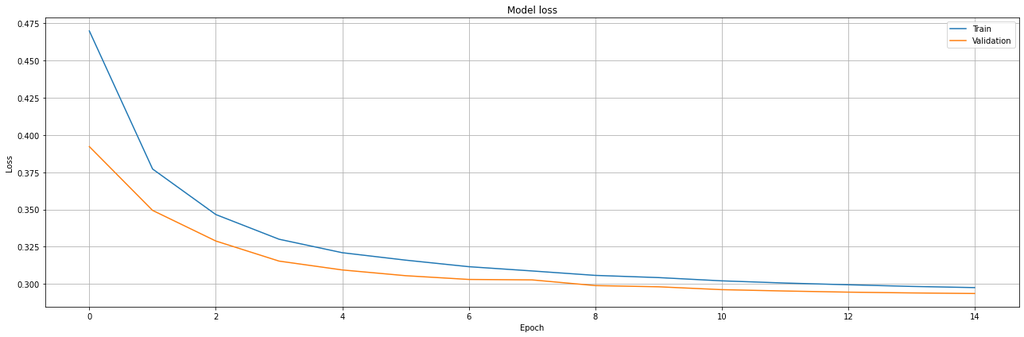

```python
plot_model_history('concat_embbeding')
```

```python
nn_model = create_concate_model()
nn_model.load_weights('/content/drive/MyDrive/DeepLearning/Assignment2/models/model_concat_embbeding.h5')
```

```python
predictions = nn_model.predict([processed_data[f] for f in processed_data.columns])
```

```python
plt.figure(figsize=(17,5))
plt.plot(y_val[:5000],c='red')
plt.plot(predictions[:5000,0])
```

[output not shown]

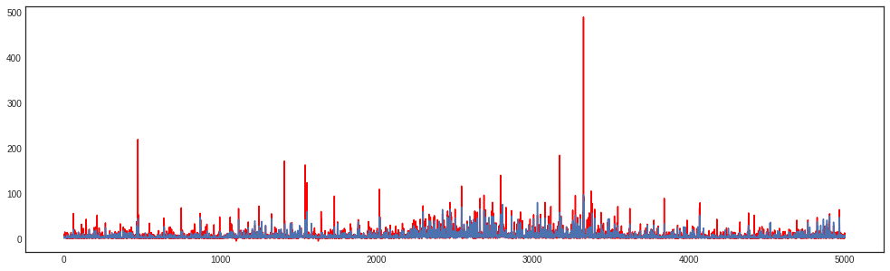

```python
plt.figure(figsize=(17,5))
plt.plot(target[:5000],c='red')
plt.plot(predictions[:5000,0])
```

We can see an improvement in the loss, and the graph is more close to recognize the extreme features, but still not doing well in recognize them.

- We can try to add LSTM and the time series part of the problem may help to classify better the extreme values.

```python
submit(predictions)
```

We scored on kaggle 2.19534

Lets try to improve our model by two things -

- let's take of the ‘state’ and the ‘local’ since we think they do not adding any logical issue for the data, and it may only confuse our model with too much information.
- Let's add more dense layers to increase the model.

```python
def create_concate_model():
  # date_nbr_inp = Input(shape=(1,),dtype='int64')
  store_nbr_inp = Input(shape=(1,),dtype='int64')
  item_nbr_inp = Input(shape=(1,),dtype='int64')
  onpromotion_nbr_inp = Input(shape=(1,),dtype='int64')
  family_nbr_inp = Input(shape=(1,),dtype='int64')
  class_nbr_inp = Input(shape=(1,),dtype='int64')
  perishable_nbr_inp = Input(shape=(1,),dtype='int64')
  transactions_nbr_inp = Input(shape=(1,),dtype='int64')
  city_nbr_inp = Input(shape=(1,),dtype='int64')
  # state_nbr_inp = Input(shape=(1,),dtype='int64')
  type_x_nbr_inp = Input(shape=(1,),dtype='int64')
  cluster_nbr_inp = Input(shape=(1,),dtype='int64')
  type_y_nbr_inp = Input(shape=(1,),dtype='int64')
  # locale_nbr_inp = Input(shape=(1,),dtype='int64')
  locale_name_nbr_inp = Input(shape=(1,),dtype='int64')
  transferred_nbr_inp = Input(shape=(1,),dtype='int64')


  # date_nbr_emb = Embedding(len(date_nbr),5,input_length=1, embeddings_regularizer=l2(1e-6))(date_nbr_inp)
  store_nbr_emb = Embedding(len(store_nbr),5,input_length=1, embeddings_regularizer=l2(1e-6))(store_nbr_inp)
  item_nbr_emb = Embedding(len(item_nbr),5,input_length=1, embeddings_regularizer=l2(1e-6))(item_nbr_inp)
  onpromotion_nbr_emb = Embedding(len(onpromotion_nbr),5,input_length=1, embeddings_regularizer=l2(1e-6))(onpromotion_nbr_inp)
  family_nbr_emb = Embedding(len(family_nbr),5,input_length=1, embeddings_regularizer=l2(1e-6))(family_nbr_inp)
  class_nbr_emb = Embedding(len(class_nbr),5,input_length=1, embeddings_regularizer=l2(1e-6))(class_nbr_inp)
  perishable_nbr_emb = Embedding(len(perishable_nbr),5,input_length=1, embeddings_regularizer=l2(1e-6))(perishable_nbr_inp)
  transactions_nbr_emb = Embedding(len(transactions_nbr),5,input_length=1, embeddings_regularizer=l2(1e-6))(transactions_nbr_inp)
  city_nbr_emb = Embedding(len(city_nbr),5,input_length=1, embeddings_regularizer=l2(1e-6))(city_nbr_inp)
  # state_nbr_emb = Embedding(len(state_nbr),5,input_length=1, embeddings_regularizer=l2(1e-6))(state_nbr_inp)
  type_x_nbr_emb = Embedding(len(type_x_nbr),5,input_length=1, embeddings_regularizer=l2(1e-6))(type_x_nbr_inp)
  cluster_nbr_emb = Embedding(len(cluster_nbr),5,input_length=1, embeddings_regularizer=l2(1e-6))(cluster_nbr_inp)
  type_y_nbr_emb = Embedding(len(type_y_nbr),5,input_length=1, embeddings_regularizer=l2(1e-6))(type_y_nbr_inp)
  # locale_nbr_emb = Embedding(len(locale_nbr),5,input_length=1, embeddings_regularizer=l2(1e-6))(locale_nbr_inp)
  locale_name_nbr_emb = Embedding(len(locale_name_nbr),5,input_length=1, embeddings_regularizer=l2(1e-6))(locale_name_nbr_inp)
  transferred_nbr_emb = Embedding(len(transferred_nbr),5,input_length=1, embeddings_regularizer=l2(1e-6))(transferred_nbr_inp)

  x = Concatenate()([store_nbr_emb,item_nbr_emb, onpromotion_nbr_emb, family_nbr_emb, class_nbr_emb, perishable_nbr_emb, transactions_nbr_emb, city_nbr_emb, type_x_nbr_emb, cluster_nbr_emb, type_y_nbr_emb, locale_name_nbr_emb, transferred_nbr_emb])
  x = Flatten()(x)
  x = BatchNormalization()(x)
  x = Dense(256,activation='relu')(x)
  x = Dense(128,activation='relu')(x)
  x = BatchNormalization()(x)
  x = Dense(64,activation='relu')(x)
  x = Dense(32,activation='relu')(x)
  x = Dropout(0.02)(x)
  x = Dense(16,activation='relu')(x)
  x = Dense(1,activation='relu')(x)
  nn_model = Model([store_nbr_inp,item_nbr_inp, onpromotion_nbr_inp, family_nbr_inp, class_nbr_inp, perishable_nbr_inp, transactions_nbr_inp, city_nbr_inp, type_x_nbr_inp, cluster_nbr_inp, type_y_nbr_inp, locale_name_nbr_inp, transferred_nbr_inp],x)
  nn_model.compile(loss = 'msle',optimizer='sgd', metrics=['acc'])
  return nn_model
```

```python
create_concate_model().summary()
```

```
Model: "model_3"
__________________________________________________________________________________________________
Layer (type)                    Output Shape         Param #     Connected to
==================================================================================================
input_66 (InputLayer)           [(None, 1)]          0
__________________________________________________________________________________________________
input_67 (InputLayer)           [(None, 1)]          0
__________________________________________________________________________________________________
input_68 (InputLayer)           [(None, 1)]          0
__________________________________________________________________________________________________
input_69 (InputLayer)           [(None, 1)]          0
__________________________________________________________________________________________________
input_70 (InputLayer)           [(None, 1)]          0
__________________________________________________________________________________________________
input_71 (InputLayer)           [(None, 1)]          0
__________________________________________________________________________________________________
input_72 (InputLayer)           [(None, 1)]          0
__________________________________________________________________________________________________
input_73 (InputLayer)           [(None, 1)]          0
__________________________________________________________________________________________________
input_74 (InputLayer)           [(None, 1)]          0
__________________________________________________________________________________________________
input_75 (InputLayer)           [(None, 1)]          0
__________________________________________________________________________________________________
input_76 (InputLayer)           [(None, 1)]          0
__________________________________________________________________________________________________
input_77 (InputLayer)           [(None, 1)]          0
__________________________________________________________________________________________________
input_78 (InputLayer)           [(None, 1)]          0
__________________________________________________________________________________________________
embedding_65 (Embedding)        (None, 1, 5)         270         input_66[0][0]
__________________________________________________________________________________________________
embedding_66 (Embedding)        (None, 1, 5)         20365       input_67[0][0]
__________________________________________________________________________________________________
embedding_67 (Embedding)        (None, 1, 5)         10          input_68[0][0]
__________________________________________________________________________________________________
embedding_68 (Embedding)        (None, 1, 5)         165         input_69[0][0]
__________________________________________________________________________________________________
embedding_69 (Embedding)        (None, 1, 5)         1665        input_70[0][0]
__________________________________________________________________________________________________
```

[output cut: 39 more lines]

```
__________________________________________________________________________________________________
dense_24 (Dense)                (None, 64)           8256        batch_normalization_23[0][0]
__________________________________________________________________________________________________
dense_25 (Dense)                (None, 32)           2080        dense_24[0][0]
__________________________________________________________________________________________________
dropout_22 (Dropout)            (None, 32)           0           dense_25[0][0]
__________________________________________________________________________________________________
dense_26 (Dense)                (None, 16)           528         dropout_22[0][0]
__________________________________________________________________________________________________
dense_27 (Dense)                (None, 1)            17          dense_26[0][0]
==================================================================================================
Total params: 93,300
Trainable params: 92,914
Non-trainable params: 386
__________________________________________________________________________________________________
```

```python
from sklearn.model_selection import KFold,StratifiedKFold

def set_callbacks(description='run1',patience=15,tb_base_logdir='./logs/'):
    cp = ModelCheckpoint('best_model_weights_{}.h5'.format(description),save_best_only=True)
    es = EarlyStopping(patience=patience,monitor='val_loss')
    rlop = ReduceLROnPlateau(patience=5)
    tb = TensorBoard(log_dir='{}{}'.format(tb_base_logdir,description))
#     cycl = CyclicLR(max_lr=0.03,step_size=5000)
    cb = [cp,es,tb,rlop]
    return cb

features = processed_data.columns


x_train, x_val, y_train, y_val = train_test_split(processed_data, target, test_size=0.2, random_state=42)


nn_model = create_concate_model()

history = nn_model.fit([x_train[f] for f in processed_data.columns], y_train, batch_size=64,
          epochs=30,
          validation_data=([x_val[f] for f in processed_data.columns], y_val),
          callbacks= get_callbacks('concat_embbeding'),
          verbose=1
         )

save_history(history, model_name='concat_embbeding')
```

```
Epoch 00001: val_loss improved from inf to 0.30489, saving model to /content/drive/MyDrive/DeepLearning/Assignment2/models/model_concat_embbeding.h5

Epoch 00002: val_loss improved from 0.30489 to 0.29064, saving model to /content/drive/MyDrive/DeepLearning/Assignment2/models/model_concat_embbeding.h5

Epoch 00003: val_loss improved from 0.29064 to 0.28661, saving model to /content/drive/MyDrive/DeepLearning/Assignment2/models/model_concat_embbeding.h5

Epoch 00004: val_loss improved from 0.28661 to 0.28203, saving model to /content/drive/MyDrive/DeepLearning/Assignment2/models/model_concat_embbeding.h5

Epoch 00005: val_loss improved from 0.28203 to 0.28036, saving model to /content/drive/MyDrive/DeepLearning/Assignment2/models/model_concat_embbeding.h5

Epoch 00006: val_loss improved from 0.28036 to 0.27706, saving model to /content/drive/MyDrive/DeepLearning/Assignment2/models/model_concat_embbeding.h5

Epoch 00007: val_loss improved from 0.27706 to 0.27595, saving model to /content/drive/MyDrive/DeepLearning/Assignment2/models/model_concat_embbeding.h5

Epoch 00008: val_loss improved from 0.27595 to 0.27435, saving model to /content/drive/MyDrive/DeepLearning/Assignment2/models/model_concat_embbeding.h5

Epoch 00009: val_loss improved from 0.27435 to 0.27282, saving model to /content/drive/MyDrive/DeepLearning/Assignment2/models/model_concat_embbeding.h5

Epoch 00010: val_loss improved from 0.27282 to 0.27169, saving model to /content/drive/MyDrive/DeepLearning/Assignment2/models/model_concat_embbeding.h5

Epoch 00011: val_loss improved from 0.27169 to 0.27119, saving model to /content/drive/MyDrive/DeepLearning/Assignment2/models/model_concat_embbeding.h5

Epoch 00012: val_loss improved from 0.27119 to 0.27061, saving model to /content/drive/MyDrive/DeepLearning/Assignment2/models/model_concat_embbeding.h5

Epoch 00013: val_loss improved from 0.27061 to 0.26997, saving model to /content/drive/MyDrive/DeepLearning/Assignment2/models/model_concat_embbeding.h5

Epoch 00014: val_loss did not improve from 0.26997

Epoch 00015: val_loss improved from 0.26997 to 0.26804, saving model to /content/drive/MyDrive/DeepLearning/Assignment2/models/model_concat_embbeding.h5

Epoch 00016: val_loss improved from 0.26804 to 0.26788, saving model to /content/drive/MyDrive/DeepLearning/Assignment2/models/model_concat_embbeding.h5

Epoch 00017: val_loss improved from 0.26788 to 0.26715, saving model to /content/drive/MyDrive/DeepLearning/Assignment2/models/model_concat_embbeding.h5

Epoch 00018: val_loss improved from 0.26715 to 0.26654, saving model to /content/drive/MyDrive/DeepLearning/Assignment2/models/model_concat_embbeding.h5

Epoch 00019: val_loss did not improve from 0.26654

Epoch 00020: val_loss did not improve from 0.26654

Epoch 00021: val_loss improved from 0.26654 to 0.26653, saving model to /content/drive/MyDrive/DeepLearning/Assignment2/models/model_concat_embbeding.h5

Epoch 00022: val_loss improved from 0.26653 to 0.26229, saving model to /content/drive/MyDrive/DeepLearning/Assignment2/models/model_concat_embbeding.h5

Epoch 00023: val_loss improved from 0.26229 to 0.26199, saving model to /content/drive/MyDrive/DeepLearning/Assignment2/models/model_concat_embbeding.h5

Epoch 00024: val_loss improved from 0.26199 to 0.26199, saving model to /content/drive/MyDrive/DeepLearning/Assignment2/models/model_concat_embbeding.h5

Epoch 00025: val_loss improved from 0.26199 to 0.26160, saving model to /content/drive/MyDrive/DeepLearning/Assignment2/models/model_concat_embbeding.h5

Epoch 00026: val_loss improved from 0.26160 to 0.26128, saving model to /content/drive/MyDrive/DeepLearning/Assignment2/models/model_concat_embbeding.h5

Epoch 00027: val_loss improved from 0.26128 to 0.26126, saving model to /content/drive/MyDrive/DeepLearning/Assignment2/models/model_concat_embbeding.h5

Epoch 00028: val_loss did not improve from 0.26126

Epoch 00029: val_loss did not improve from 0.26126

Epoch 00030: val_loss improved from 0.26126 to 0.26084, saving model to /content/drive/MyDrive/DeepLearning/Assignment2/models/model_concat_embbeding.h5
```

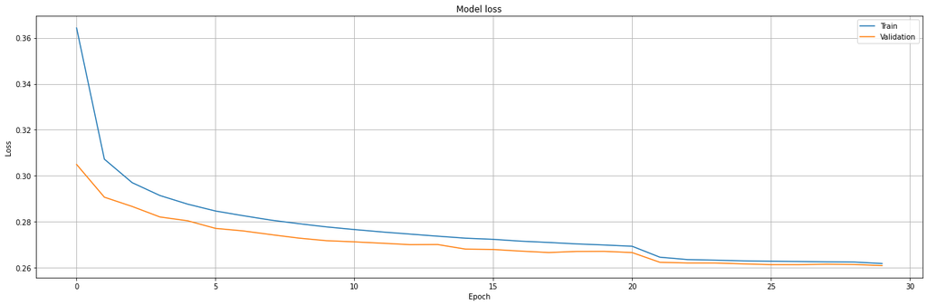

```python
plot_model_history('concat_embbeding')
```

```python
nn_model = create_concate_model()
nn_model.load_weights('/content/drive/MyDrive/DeepLearning/Assignment2/models/model_concat_embbeding.h5')
```

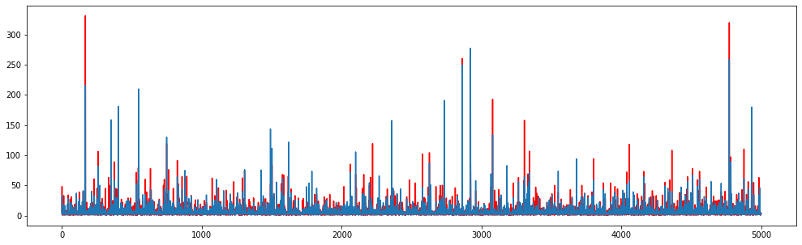

```python
plt.figure(figsize=(17,5))
plt.plot(y_val[:5000],c='red')
plt.plot(predictions[:5000,0])
```

```python
predictions = nn_model.predict([processed_test_data[f] for f in processed_test_data.columns])
flat = [item for sublist in predictions for item in sublist]
submit(flat)
```

we received on kaggle submission 1.16948.

- We improved the random forest regressor benchmark!
- We can see that the algorithm recognizes the extreme features much better.

Try with LSTM

```python
def create_concate_model_lstm():
  # date_nbr_inp = Input(shape=(1,),dtype='int64')
  store_nbr_inp = Input(shape=(1,),dtype='int64')
  item_nbr_inp = Input(shape=(1,),dtype='int64')
  onpromotion_nbr_inp = Input(shape=(1,),dtype='int64')
  family_nbr_inp = Input(shape=(1,),dtype='int64')
  class_nbr_inp = Input(shape=(1,),dtype='int64')
  perishable_nbr_inp = Input(shape=(1,),dtype='int64')
  transactions_nbr_inp = Input(shape=(1,),dtype='int64')
  city_nbr_inp = Input(shape=(1,),dtype='int64')
  state_nbr_inp = Input(shape=(1,),dtype='int64')
  type_x_nbr_inp = Input(shape=(1,),dtype='int64')
  cluster_nbr_inp = Input(shape=(1,),dtype='int64')
  type_y_nbr_inp = Input(shape=(1,),dtype='int64')
  locale_nbr_inp = Input(shape=(1,),dtype='int64')
  locale_name_nbr_inp = Input(shape=(1,),dtype='int64')
  transferred_nbr_inp = Input(shape=(1,),dtype='int64')


  # date_nbr_emb = Embedding(len(date_nbr),5,input_length=1, embeddings_regularizer=l2(1e-6))(date_nbr_inp)
  store_nbr_emb = Embedding(len(store_nbr),5,input_length=1, embeddings_regularizer=l2(1e-6))(store_nbr_inp)
  item_nbr_emb = Embedding(len(item_nbr),5,input_length=1, embeddings_regularizer=l2(1e-6))(item_nbr_inp)
  onpromotion_nbr_emb = Embedding(len(onpromotion_nbr),5,input_length=1, embeddings_regularizer=l2(1e-6))(onpromotion_nbr_inp)
  family_nbr_emb = Embedding(len(family_nbr),5,input_length=1, embeddings_regularizer=l2(1e-6))(family_nbr_inp)
  class_nbr_emb = Embedding(len(class_nbr),5,input_length=1, embeddings_regularizer=l2(1e-6))(class_nbr_inp)
  perishable_nbr_emb = Embedding(len(perishable_nbr),5,input_length=1, embeddings_regularizer=l2(1e-6))(perishable_nbr_inp)
  transactions_nbr_emb = Embedding(len(transactions_nbr),5,input_length=1, embeddings_regularizer=l2(1e-6))(transactions_nbr_inp)
  city_nbr_emb = Embedding(len(city_nbr),5,input_length=1, embeddings_regularizer=l2(1e-6))(city_nbr_inp)
  state_nbr_emb = Embedding(len(state_nbr),5,input_length=1, embeddings_regularizer=l2(1e-6))(state_nbr_inp)
  type_x_nbr_emb = Embedding(len(type_x_nbr),5,input_length=1, embeddings_regularizer=l2(1e-6))(type_x_nbr_inp)
  cluster_nbr_emb = Embedding(len(cluster_nbr),5,input_length=1, embeddings_regularizer=l2(1e-6))(cluster_nbr_inp)
  type_y_nbr_emb = Embedding(len(type_y_nbr),5,input_length=1, embeddings_regularizer=l2(1e-6))(type_y_nbr_inp)
  locale_nbr_emb = Embedding(len(locale_nbr),5,input_length=1, embeddings_regularizer=l2(1e-6))(locale_nbr_inp)
  locale_name_nbr_emb = Embedding(len(locale_name_nbr),5,input_length=1, embeddings_regularizer=l2(1e-6))(locale_name_nbr_inp)
  transferred_nbr_emb = Embedding(len(transferred_nbr),5,input_length=1, embeddings_regularizer=l2(1e-6))(transferred_nbr_inp)

  x = Concatenate()([store_nbr_emb,item_nbr_emb, onpromotion_nbr_emb, family_nbr_emb, class_nbr_emb, perishable_nbr_emb, transactions_nbr_emb, city_nbr_emb, state_nbr_emb, type_x_nbr_emb, cluster_nbr_emb, type_y_nbr_emb, locale_nbr_emb, locale_name_nbr_emb, transferred_nbr_emb])
  x = LSTM(512)(x)
  x = Flatten()(x)
  x = BatchNormalization()(x)
  x = Dropout(0.2)(x)

  x = Dense(256,activation='relu')(x)
  x = BatchNormalization()(x)
  x = Dropout(0.1)(x)

  x = Dense(128,activation='relu')(x)
  x = BatchNormalization()(x)
  x = Dropout(0.1)(x)

  x = Dense(64,activation='relu')(x)
  x = BatchNormalization()(x)
  x = Dropout(0.1)(x)

  x = Dense(32,activation='relu')(x)
  x = BatchNormalization()(x)
  x = Dropout(0.05)(x)

  x = Dense(16,activation='relu')(x)
  x = BatchNormalization()(x)
  x = Dropout(0.1)(x)

  x = Dense(1)(x)

  nn_model = Model([store_nbr_inp,item_nbr_inp, onpromotion_nbr_inp, family_nbr_inp, class_nbr_inp, perishable_nbr_inp, transactions_nbr_inp, city_nbr_inp, state_nbr_inp, type_x_nbr_inp, cluster_nbr_inp, type_y_nbr_inp, locale_nbr_inp, locale_name_nbr_inp, transferred_nbr_inp],x)
  nn_model.compile(loss = 'msle',optimizer='sgd', metrics=['mse', 'mae', 'msle'])
  return nn_model
```

```python
create_concate_model_lstm().summary()
```

```
Model: "model_1"
__________________________________________________________________________________________________
Layer (type)                    Output Shape         Param #     Connected to
==================================================================================================
input_16 (InputLayer)           [(None, 1)]          0
__________________________________________________________________________________________________
input_17 (InputLayer)           [(None, 1)]          0
__________________________________________________________________________________________________
input_18 (InputLayer)           [(None, 1)]          0
__________________________________________________________________________________________________
input_19 (InputLayer)           [(None, 1)]          0
__________________________________________________________________________________________________
input_20 (InputLayer)           [(None, 1)]          0
__________________________________________________________________________________________________
input_21 (InputLayer)           [(None, 1)]          0
__________________________________________________________________________________________________
input_22 (InputLayer)           [(None, 1)]          0
__________________________________________________________________________________________________
input_23 (InputLayer)           [(None, 1)]          0
__________________________________________________________________________________________________
input_24 (InputLayer)           [(None, 1)]          0
__________________________________________________________________________________________________
input_25 (InputLayer)           [(None, 1)]          0
__________________________________________________________________________________________________
input_26 (InputLayer)           [(None, 1)]          0
__________________________________________________________________________________________________
input_27 (InputLayer)           [(None, 1)]          0
__________________________________________________________________________________________________
input_28 (InputLayer)           [(None, 1)]          0
__________________________________________________________________________________________________
input_29 (InputLayer)           [(None, 1)]          0
__________________________________________________________________________________________________
input_30 (InputLayer)           [(None, 1)]          0
__________________________________________________________________________________________________
embedding_15 (Embedding)        (None, 1, 5)         270         input_16[0][0]
__________________________________________________________________________________________________
embedding_16 (Embedding)        (None, 1, 5)         20365       input_17[0][0]
__________________________________________________________________________________________________
embedding_17 (Embedding)        (None, 1, 5)         10          input_18[0][0]
__________________________________________________________________________________________________
```

[output cut: 69 more lines]

```
__________________________________________________________________________________________________
dropout_10 (Dropout)            (None, 32)           0           batch_normalization_10[0][0]
__________________________________________________________________________________________________
dense_10 (Dense)                (None, 16)           528         dropout_10[0][0]
__________________________________________________________________________________________________
batch_normalization_11 (BatchNo (None, 16)           64          dense_10[0][0]
__________________________________________________________________________________________________
dropout_11 (Dropout)            (None, 16)           0           batch_normalization_11[0][0]
__________________________________________________________________________________________________
dense_11 (Dense)                (None, 1)            17          dropout_11[0][0]
==================================================================================================
Total params: 1,415,306
Trainable params: 1,413,290
Non-trainable params: 2,016
__________________________________________________________________________________________________
```

```python
from sklearn.model_selection import KFold,StratifiedKFold
from sklearn.model_selection   import train_test_split

def create_window(x, y, size, jump):
  x_ret = np.array([[x[f][i:i+size] for i in range(0, len(x[f])-size, jump)] for f in x.columns])
  y_ret = np.array([y[i:i+size] for i in range(0, len(y)-size, jump)])
  return x_ret, y_ret


def set_callbacks(description='run1',patience=15,tb_base_logdir='./logs/'):
    cp = ModelCheckpoint('best_model_weights_{}.h5'.format(description),save_best_only=True)
    es = EarlyStopping(patience=patience,monitor='val_loss')
    rlop = ReduceLROnPlateau(patience=5)
    tb = TensorBoard(log_dir='{}{}'.format(tb_base_logdir,description))
#     cycl = CyclicLR(max_lr=0.03,step_size=5000)
    cb = [cp,es,tb,rlop]
    return cb

features = processed_data.columns

x_train, x_val, y_train, y_val = train_test_split(processed_data, target, test_size=0.2, random_state=42, shuffle=False)


nn_model = create_concate_model()

history = nn_model.fit([x_train[f] for f in x_train.columns], y_train, batch_size=64,
          epochs=15,
          validation_data=([x_val[f] for f in x_val.columns], y_val),
          callbacks= get_callbacks('concate_embbeding_7:07'),
          verbose=0
         )

save_history(history, model_name='concate_embbeding_7:07')
```

```
Epoch 00001: val_loss improved from inf to 0.34874, saving model to /content/drive/MyDrive/DeepLearning/Assignment2/models/model_concate_embbeding_7:07.h5

Epoch 00002: val_loss improved from 0.34874 to 0.33595, saving model to /content/drive/MyDrive/DeepLearning/Assignment2/models/model_concate_embbeding_7:07.h5

Epoch 00003: val_loss improved from 0.33595 to 0.32841, saving model to /content/drive/MyDrive/DeepLearning/Assignment2/models/model_concate_embbeding_7:07.h5

Epoch 00004: val_loss improved from 0.32841 to 0.32576, saving model to /content/drive/MyDrive/DeepLearning/Assignment2/models/model_concate_embbeding_7:07.h5

Epoch 00005: val_loss improved from 0.32576 to 0.32278, saving model to /content/drive/MyDrive/DeepLearning/Assignment2/models/model_concate_embbeding_7:07.h5

Epoch 00006: val_loss did not improve from 0.32278

Epoch 00007: val_loss improved from 0.32278 to 0.31950, saving model to /content/drive/MyDrive/DeepLearning/Assignment2/models/model_concate_embbeding_7:07.h5

Epoch 00008: val_loss did not improve from 0.31950

Epoch 00009: val_loss improved from 0.31950 to 0.31915, saving model to /content/drive/MyDrive/DeepLearning/Assignment2/models/model_concate_embbeding_7:07.h5

Epoch 00010: val_loss did not improve from 0.31915

Epoch 00011: val_loss did not improve from 0.31915

Epoch 00012: val_loss improved from 0.31915 to 0.31856, saving model to /content/drive/MyDrive/DeepLearning/Assignment2/models/model_concate_embbeding_7:07.h5

Epoch 00013: val_loss improved from 0.31856 to 0.31701, saving model to /content/drive/MyDrive/DeepLearning/Assignment2/models/model_concate_embbeding_7:07.h5

Epoch 00014: val_loss did not improve from 0.31701

Epoch 00015: val_loss did not improve from 0.31701
```

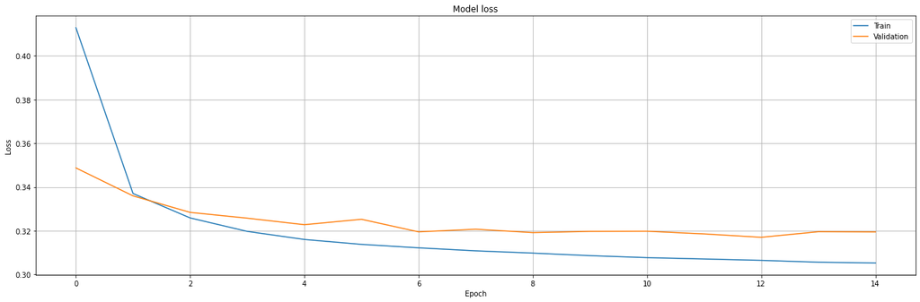

```python
plot_model_history('concate_embbeding_7:07')
```

```python
predictions = nn_model.predict([x_val[f] for f in x_val.columns])
```

```python
from sklearn.metrics import mean_squared_error

rms = mean_squared_error(y_val[:5000], predictions[:5000,0], squared=False)
print(rms)
```

```
9.885815
```

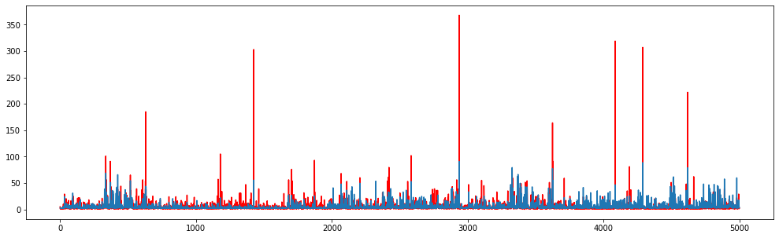

```python
plt.figure(figsize=(17,5))
plt.plot(y_val[:5000],c='red')
plt.plot(predictions[:5000,0])
```

**3f)** Interesting insights we got from the embeddings of categorical features -

- Use of categorical embeddings may help with adapting the data analysis to the relevant features.
- We can see that adding embeddings receives better results than the simple algorithm.
- On complicated data like we work with here, we need to adapt an outstanding model in order to receive better results than the model, and only adding the embeddings is not enough.
- We still believe that adding LSTM in this type of problems may perform good results, even though we didn't succeed in doing it.

**3g)Feature Extractor**

```python
for layer_idx in range(len(nn_model.layers)):
    print(layer_idx, nn_model.layers[layer_idx])
```

```
0 <tensorflow.python.keras.engine.input_layer.InputLayer object at 0x7f1129214470>
1 <tensorflow.python.keras.engine.input_layer.InputLayer object at 0x7f1125aadd30>
2 <tensorflow.python.keras.engine.input_layer.InputLayer object at 0x7f1129a9f080>
3 <tensorflow.python.keras.engine.input_layer.InputLayer object at 0x7f1129a9f390>
4 <tensorflow.python.keras.engine.input_layer.InputLayer object at 0x7f1129a9f6a0>
5 <tensorflow.python.keras.engine.input_layer.InputLayer object at 0x7f1129a9f9b0>
6 <tensorflow.python.keras.engine.input_layer.InputLayer object at 0x7f1129a9fcf8>
7 <tensorflow.python.keras.engine.input_layer.InputLayer object at 0x7f1125a52048>
8 <tensorflow.python.keras.engine.input_layer.InputLayer object at 0x7f1125a52358>
9 <tensorflow.python.keras.engine.input_layer.InputLayer object at 0x7f1125a52668>
10 <tensorflow.python.keras.engine.input_layer.InputLayer object at 0x7f1125a52978>
11 <tensorflow.python.keras.engine.input_layer.InputLayer object at 0x7f1125a52c88>
12 <tensorflow.python.keras.engine.input_layer.InputLayer object at 0x7f1125a52f98>
13 <tensorflow.python.keras.layers.embeddings.Embedding object at 0x7f1125a51320>
14 <tensorflow.python.keras.layers.embeddings.Embedding object at 0x7f1125a51a20>
```

[output cut: 22 more lines]

```python
for layer in nn_model.layers:
    layer.trainable = False

nn_model.summary()
```

```
Model: "model_1"
__________________________________________________________________________________________________
Layer (type)                    Output Shape         Param #     Connected to
==================================================================================================
input_14 (InputLayer)           [(None, 1)]          0
__________________________________________________________________________________________________
input_15 (InputLayer)           [(None, 1)]          0
__________________________________________________________________________________________________
input_16 (InputLayer)           [(None, 1)]          0
__________________________________________________________________________________________________
input_17 (InputLayer)           [(None, 1)]          0
__________________________________________________________________________________________________
input_18 (InputLayer)           [(None, 1)]          0
__________________________________________________________________________________________________
input_19 (InputLayer)           [(None, 1)]          0
__________________________________________________________________________________________________
input_20 (InputLayer)           [(None, 1)]          0
__________________________________________________________________________________________________
input_21 (InputLayer)           [(None, 1)]          0
__________________________________________________________________________________________________
input_22 (InputLayer)           [(None, 1)]          0
__________________________________________________________________________________________________
input_23 (InputLayer)           [(None, 1)]          0
__________________________________________________________________________________________________
input_24 (InputLayer)           [(None, 1)]          0
__________________________________________________________________________________________________
input_25 (InputLayer)           [(None, 1)]          0
__________________________________________________________________________________________________
input_26 (InputLayer)           [(None, 1)]          0
__________________________________________________________________________________________________
embedding_13 (Embedding)        (None, 1, 5)         270         input_14[0][0]
__________________________________________________________________________________________________
embedding_14 (Embedding)        (None, 1, 5)         20365       input_15[0][0]
__________________________________________________________________________________________________
embedding_15 (Embedding)        (None, 1, 5)         10          input_16[0][0]
__________________________________________________________________________________________________
embedding_16 (Embedding)        (None, 1, 5)         165         input_17[0][0]
__________________________________________________________________________________________________
embedding_17 (Embedding)        (None, 1, 5)         1665        input_18[0][0]
__________________________________________________________________________________________________
```

[output cut: 39 more lines]

```
__________________________________________________________________________________________________
dense_8 (Dense)                 (None, 64)           8256        batch_normalization_3[0][0]
__________________________________________________________________________________________________
dense_9 (Dense)                 (None, 32)           2080        dense_8[0][0]
__________________________________________________________________________________________________
dropout_1 (Dropout)             (None, 32)           0           dense_9[0][0]
__________________________________________________________________________________________________
dense_10 (Dense)                (None, 16)           528         dropout_1[0][0]
__________________________________________________________________________________________________
dense_11 (Dense)                (None, 1)            17          dense_10[0][0]
==================================================================================================
Total params: 93,300
Trainable params: 0
Non-trainable params: 93,300
__________________________________________________________________________________________________
```

```python
nn_model_extract = Model(inputs=nn_model.inputs, outputs=nn_model.layers[-2].output)
nn_model_extract.summary()
```

```
Model: "model_2"
__________________________________________________________________________________________________
Layer (type)                    Output Shape         Param #     Connected to
==================================================================================================
input_14 (InputLayer)           [(None, 1)]          0
__________________________________________________________________________________________________
input_15 (InputLayer)           [(None, 1)]          0
__________________________________________________________________________________________________
input_16 (InputLayer)           [(None, 1)]          0
__________________________________________________________________________________________________
input_17 (InputLayer)           [(None, 1)]          0
__________________________________________________________________________________________________
input_18 (InputLayer)           [(None, 1)]          0
__________________________________________________________________________________________________
input_19 (InputLayer)           [(None, 1)]          0
__________________________________________________________________________________________________
input_20 (InputLayer)           [(None, 1)]          0
__________________________________________________________________________________________________
input_21 (InputLayer)           [(None, 1)]          0
__________________________________________________________________________________________________
input_22 (InputLayer)           [(None, 1)]          0
__________________________________________________________________________________________________
input_23 (InputLayer)           [(None, 1)]          0
__________________________________________________________________________________________________
input_24 (InputLayer)           [(None, 1)]          0
__________________________________________________________________________________________________
input_25 (InputLayer)           [(None, 1)]          0
__________________________________________________________________________________________________
input_26 (InputLayer)           [(None, 1)]          0
__________________________________________________________________________________________________
embedding_13 (Embedding)        (None, 1, 5)         270         input_14[0][0]
__________________________________________________________________________________________________
embedding_14 (Embedding)        (None, 1, 5)         20365       input_15[0][0]
__________________________________________________________________________________________________
embedding_15 (Embedding)        (None, 1, 5)         10          input_16[0][0]
__________________________________________________________________________________________________
embedding_16 (Embedding)        (None, 1, 5)         165         input_17[0][0]
__________________________________________________________________________________________________
embedding_17 (Embedding)        (None, 1, 5)         1665        input_18[0][0]
__________________________________________________________________________________________________
```

[output cut: 37 more lines]

```
__________________________________________________________________________________________________
batch_normalization_3 (BatchNor (None, 128)          512         dense_7[0][0]
__________________________________________________________________________________________________
dense_8 (Dense)                 (None, 64)           8256        batch_normalization_3[0][0]
__________________________________________________________________________________________________
dense_9 (Dense)                 (None, 32)           2080        dense_8[0][0]
__________________________________________________________________________________________________
dropout_1 (Dropout)             (None, 32)           0           dense_9[0][0]
__________________________________________________________________________________________________
dense_10 (Dense)                (None, 16)           528         dropout_1[0][0]
==================================================================================================
Total params: 93,283
Trainable params: 0
Non-trainable params: 93,283
__________________________________________________________________________________________________
```

```python
def extract_features(model, X):
    return model.predict(X)
```

```python
model_features = extract_features(nn_model_extract, [processed_data[f] for f in processed_data.columns])
```

```python
from sklearn.ensemble import RandomForestRegressor
from sklearn.model_selection   import train_test_split
rf = RandomForestRegressor(n_estimators=5, verbose=2)
rf.fit(model_features, target)
```

```
[Parallel(n_jobs=1)]: Using backend SequentialBackend with 1 concurrent workers.
```

```
building tree 1 of 5
```

```
[Parallel(n_jobs=1)]: Done   1 out of   1 | elapsed:  2.3min remaining:    0.0s
```

```
building tree 2 of 5
building tree 3 of 5
building tree 4 of 5
building tree 5 of 5
```

```
[Parallel(n_jobs=1)]: Done   5 out of   5 | elapsed: 11.2min finished
```

```
RandomForestRegressor(bootstrap=True, ccp_alpha=0.0, criterion='mse',
                      max_depth=None, max_features='auto', max_leaf_nodes=None,
                      max_samples=None, min_impurity_decrease=0.0,
                      min_impurity_split=None, min_samples_leaf=1,
                      min_samples_split=2, min_weight_fraction_leaf=0.0,
                      n_estimators=5, n_jobs=None, oob_score=False,
                      random_state=None, verbose=2, warm_start=False)
```

```python
import numpy as np
from sklearn.metrics import mean_absolute_error
predictions = rf.predict(model_features)
# errors = abs(predictions - target)
# print('Mean Absolute Error:', round(np.mean(errors), 2), 'degrees.')
mean_absolute_error(target, predictions)
```

```
[Parallel(n_jobs=1)]: Using backend SequentialBackend with 1 concurrent workers.
[Parallel(n_jobs=1)]: Done   1 out of   1 | elapsed:    6.3s remaining:    0.0s
[Parallel(n_jobs=1)]: Done   5 out of   5 | elapsed:   32.2s finished
```

```
1.645112086981476
```

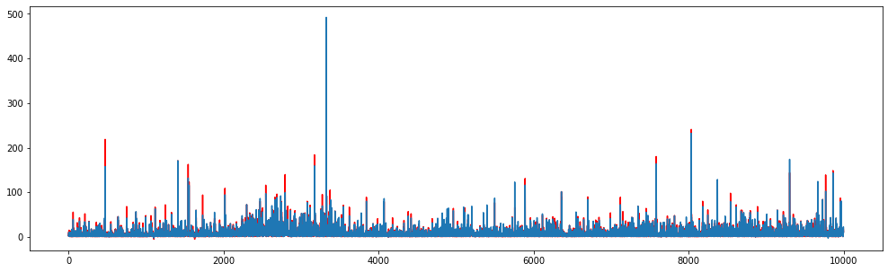

```python
plt.figure(figsize=(17,5))
plt.plot(target[:10000],c='red')
plt.plot(predictions[:10000])
```

**We can see that the results are much better than our result, the extreme values recognized very well!**